# Homework 3 Visualizations & Simulations

Author

Andrew Joyce

Published

September 18, 2023

## 3.1.1.1 Exercise

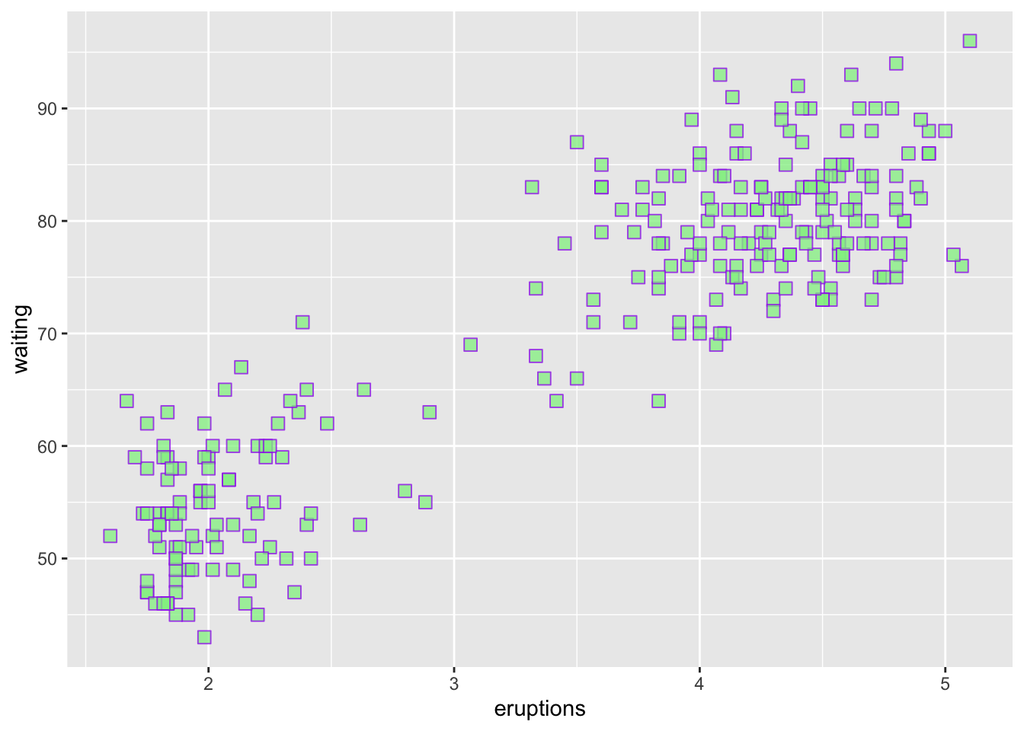

```r
# make the points larger squares, and slightly transparent
ggplot(faithful) +
  geom_point(aes(x = eruptions, y = waiting),
             shape="square fill", size=3, color= "purple",
             fill="lightgreen", alpha=0.75)
```

## 3.1.1.2 Exercise

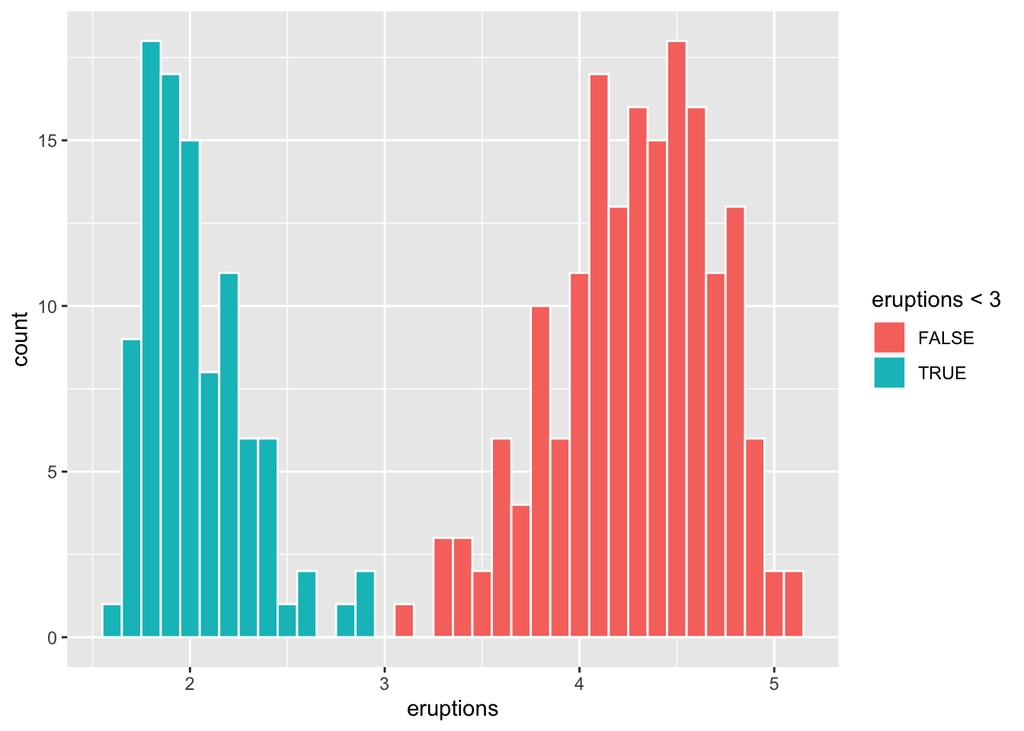

```r
# color the two visible clusters in the diagram with different colors
ggplot(faithful) +
  geom_histogram(aes(x = eruptions, fill = eruptions < 3 ),
                 binwidth=0.10, color="white")
```

## 3.1.1.3 Exercise

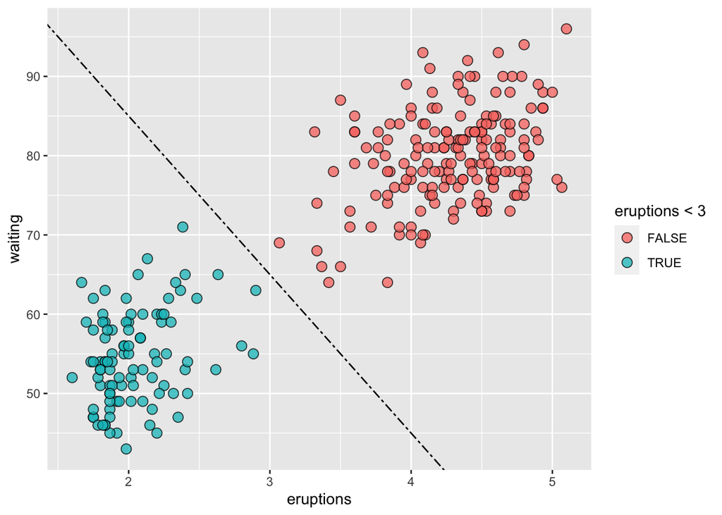

```r
# Add a line that separates the two point distributions.
ggplot(faithful) +
  geom_point(aes(x = eruptions, y = waiting, fill = eruptions < 3),
                 shape="circle fill", size=3, color= "black", alpha=0.75) +
  geom_abline(slope = -20, intercept = 125, linetype="twodash", color="black")
```

## 3.1.3.1 Excerise

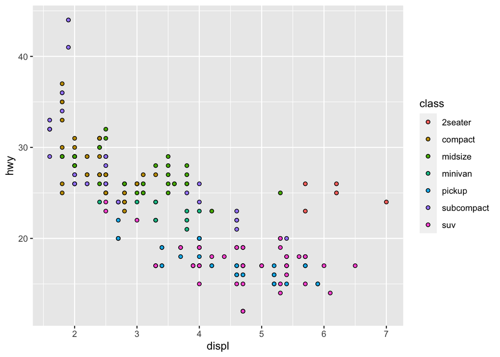

```r
# Modify the code below to use a palette from Color Brewer.
ggplot(mpg) +
  geom_point(aes(x = displ, y = hwy, fill = class), shape="circle filled") +
  scale_color_brewer(palette = 'Set1')
```

## 3.1.3.2 Exercise

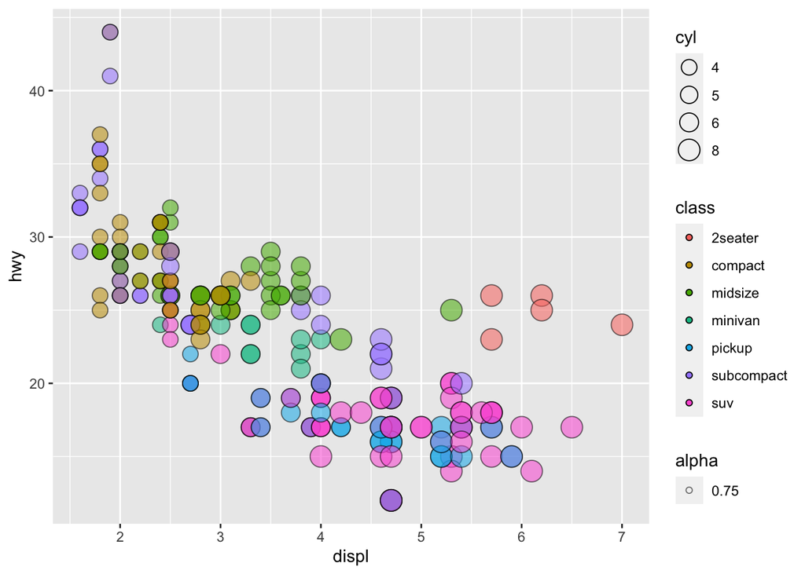

```r
# Modify the code below to create a bubble chart (scatterplot with size mapped to a continuous variable) showing cyl with size.

ggplot(mpg) +
  geom_point(aes(x = displ, y = hwy, fill = class, size = cyl, alpha = 0.75), shape = "circle filled") +
  scale_color_brewer(palette = "Set1") +
  scale_size_area(breaks = c(4, 5, 6, 8))
```

## 3.1.3.3 Exercise

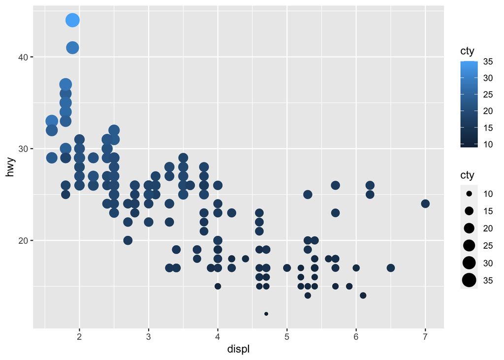

```r
# Modify the code below so that color is no longer mapped to the discrete class variable, but to the continuous cty variable. What happens to the guide?
ggplot(mpg) +
  geom_point(aes(x = displ, y = hwy, color = cty, size = cty))
```

After mapping the continuous variable `cty` onto color, we see a gradient in the legend, where darker values mean lower values of `cty`. Gradients are cool because they show how color can be continuous- so we have a continuous color mapping onto a continuous variable.

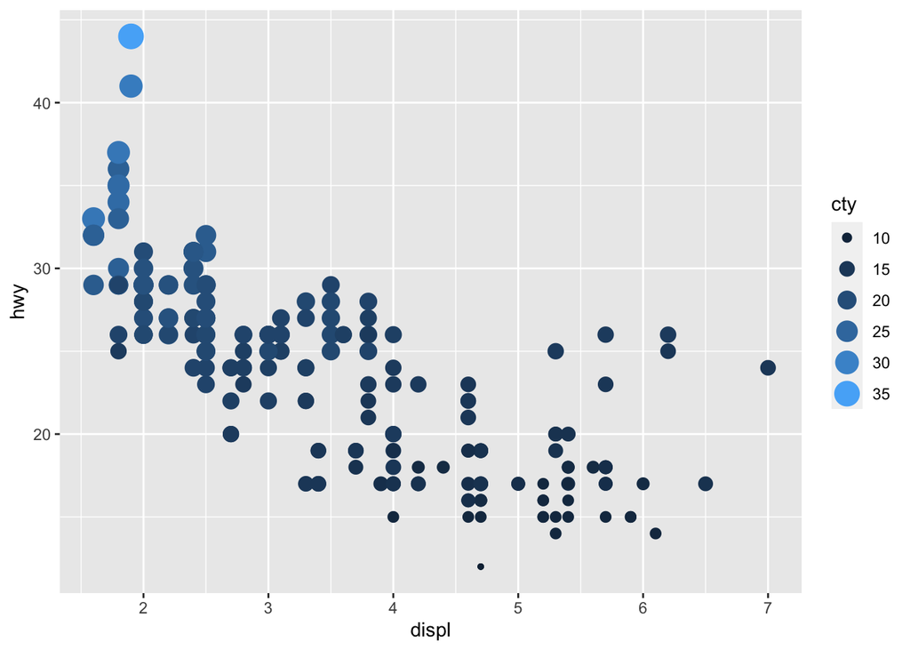

```r
# What happens when multiple aesthetics are mapped to the same variable and uses the guide type?
ggplot(mpg) +
  geom_point(aes(x = displ, y = hwy, color = cty, size = cty)) +
  guides(color = "legend")
```

After mapping two aesthetics (color and size) to the same variable (cty), the legends combine. Gradient of blue & size of circle are mapped onto values of cty.

## 3.1.4.1 Exercise

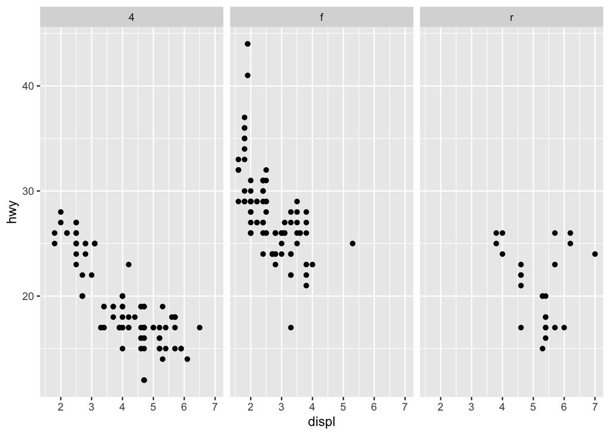

```r
# Experiment with the different possible settings for scales in the plot below:

# original; default is scales = "fixed"
ggplot(mpg) +
  geom_point(aes(x = displ, y = hwy)) +
  facet_wrap(~ drv)
```

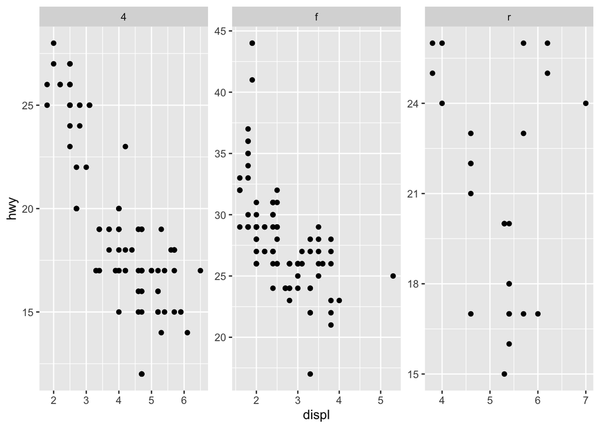

```r
# scales = "free", which adjusts both x and y axes to the data
ggplot(mpg) +
  geom_point(aes(x = displ, y = hwy)) +
  facet_wrap(~ drv, scales = "free")
```

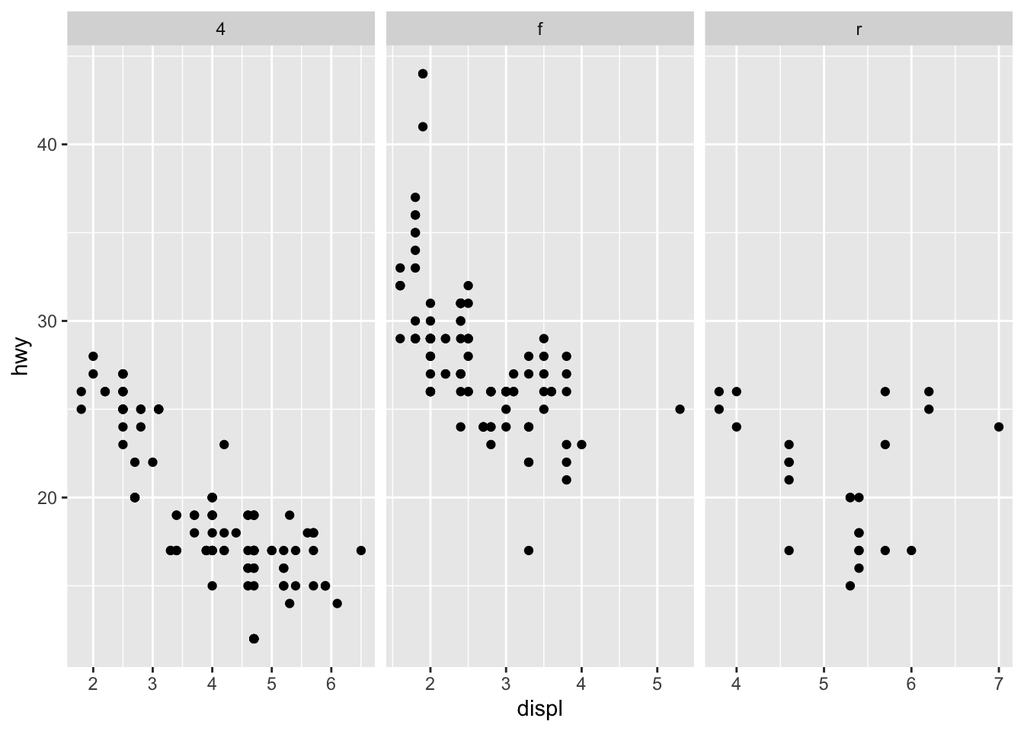

```r
# scales = "free_x", which restricts the y axis and lets x axes vary
ggplot(mpg) +
  geom_point(aes(x = displ, y = hwy)) +
  facet_wrap(~ drv, scales = "free_x")
```

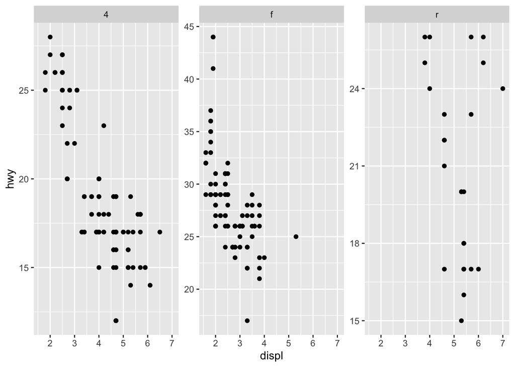

```r
# scales = "free_y", which restricts the x axis and lets the y axes vary
ggplot(mpg) +
  geom_point(aes(x = displ, y = hwy)) +
  facet_wrap(~ drv, scales = "free_y")
```

## 3.1.5.1 Exercise

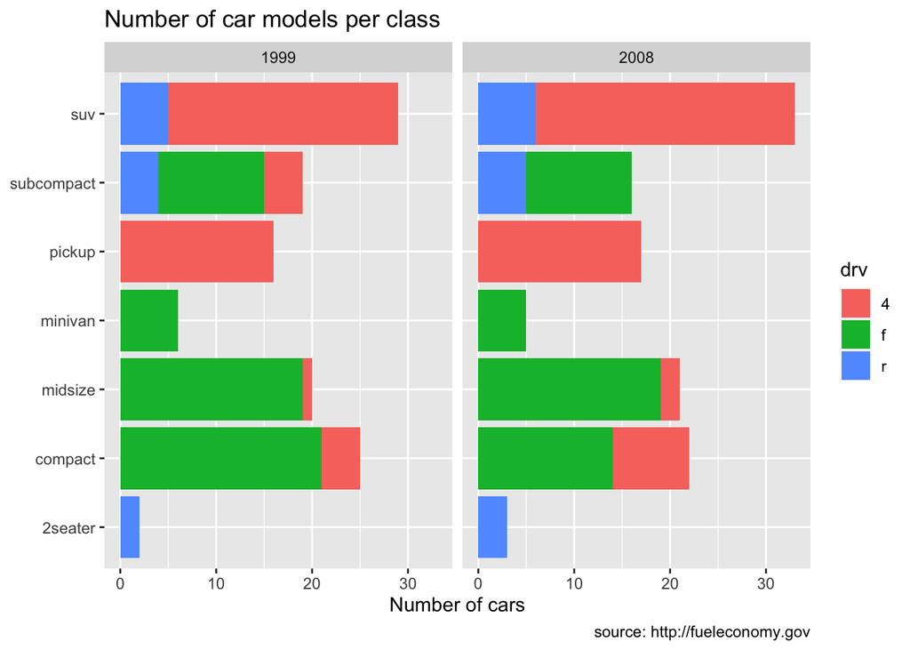

```r
# original plot
mpg |>
  ggplot(aes(y = class, fill = drv)) +
  geom_bar() +
  facet_wrap(~year) +
  labs(
    title = "Number of car models per class",
    caption = "source: http://fueleconomy.gov",
    x = 'Number of cars',
    y = NULL
  )
```

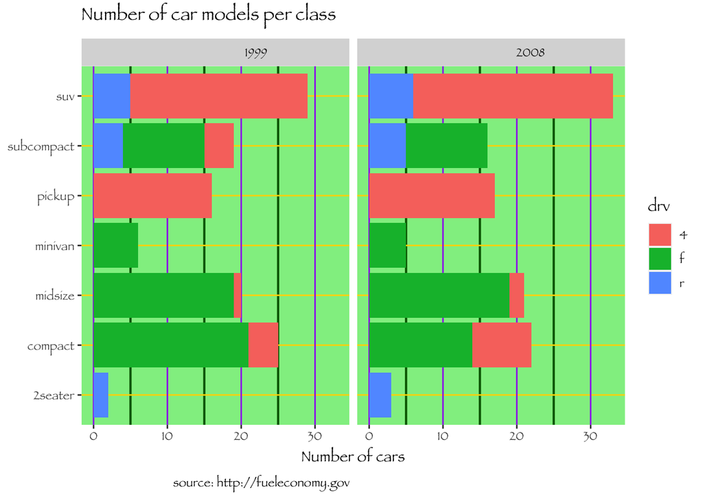

```r
# make it as ugly as possible using the theme function
mpg |>
  ggplot(aes(y = class, fill = drv)) +
  geom_bar() +
  facet_wrap(~year) +
  labs(
    title = "Number of car models per class",
    caption = "source: http://fueleconomy.gov",
    x = 'Number of cars',
    y = NULL
  ) +
  theme (
    text = element_text('Papyrus'),
    strip.text = element_text(face = 'italic', hjust = 0.675),
    plot.caption = element_text(face = 'bold', hjust = 0.25),
    panel.grid.major = element_line('purple', linewidth = 0.5),
    panel.grid.minor = element_line('darkgreen', linewidth = 0.75),
    panel.grid.major.y = element_line("gold", linewidth = 0.5),
    panel.background = element_rect(fill = "lightgreen"),
    panel.ontop = FALSE
  )
```